# Red Wine Quality Exploration by Xianglian Ni

> This dataset contains variables on the chemical properties of 1599 red wines. At least 3 wine experts rated the quality of each wine, providing a rating between 0 (very bad) and 10 (very excellent).

# Univariate Plots Section

```
## 'data.frame':    1599 obs. of  13 variables:
##  $ X                   : int  1 2 3 4 5 6 7 8 9 10 ...
##  $ fixed.acidity       : num  7.4 7.8 7.8 11.2 7.4 7.4 7.9 7.3 7.8 7.5 ...
##  $ volatile.acidity    : num  0.7 0.88 0.76 0.28 0.7 0.66 0.6 0.65 0.58 0.5 ...
##  $ citric.acid         : num  0 0 0.04 0.56 0 0 0.06 0 0.02 0.36 ...
##  $ residual.sugar      : num  1.9 2.6 2.3 1.9 1.9 1.8 1.6 1.2 2 6.1 ...
##  $ chlorides           : num  0.076 0.098 0.092 0.075 0.076 0.075 0.069 0.065 0.073 0.071 ...
##  $ free.sulfur.dioxide : num  11 25 15 17 11 13 15 15 9 17 ...
##  $ total.sulfur.dioxide: num  34 67 54 60 34 40 59 21 18 102 ...
##  $ density             : num  0.998 0.997 0.997 0.998 0.998 ...
##  $ pH                  : num  3.51 3.2 3.26 3.16 3.51 3.51 3.3 3.39 3.36 3.35 ...
##  $ sulphates           : num  0.56 0.68 0.65 0.58 0.56 0.56 0.46 0.47 0.57 0.8 ...
##  $ alcohol             : num  9.4 9.8 9.8 9.8 9.4 9.4 9.4 10 9.5 10.5 ...
##  $ quality             : int  5 5 5 6 5 5 5 7 7 5 ...
```

```
##        X          fixed.acidity   volatile.acidity  citric.acid
##  Min.   :   1.0   Min.   : 4.60   Min.   :0.1200   Min.   :0.000
##  1st Qu.: 400.5   1st Qu.: 7.10   1st Qu.:0.3900   1st Qu.:0.090
##  Median : 800.0   Median : 7.90   Median :0.5200   Median :0.260
##  Mean   : 800.0   Mean   : 8.32   Mean   :0.5278   Mean   :0.271
##  3rd Qu.:1199.5   3rd Qu.: 9.20   3rd Qu.:0.6400   3rd Qu.:0.420
##  Max.   :1599.0   Max.   :15.90   Max.   :1.5800   Max.   :1.000
##  residual.sugar     chlorides       free.sulfur.dioxide
##  Min.   : 0.900   Min.   :0.01200   Min.   : 1.00
##  1st Qu.: 1.900   1st Qu.:0.07000   1st Qu.: 7.00
##  Median : 2.200   Median :0.07900   Median :14.00
##  Mean   : 2.539   Mean   :0.08747   Mean   :15.87
##  3rd Qu.: 2.600   3rd Qu.:0.09000   3rd Qu.:21.00
##  Max.   :15.500   Max.   :0.61100   Max.   :72.00
##  total.sulfur.dioxide    density             pH          sulphates
##  Min.   :  6.00       Min.   :0.9901   Min.   :2.740   Min.   :0.3300
##  1st Qu.: 22.00       1st Qu.:0.9956   1st Qu.:3.210   1st Qu.:0.5500
##  Median : 38.00       Median :0.9968   Median :3.310   Median :0.6200
##  Mean   : 46.47       Mean   :0.9967   Mean   :3.311   Mean   :0.6581
##  3rd Qu.: 62.00       3rd Qu.:0.9978   3rd Qu.:3.400   3rd Qu.:0.7300
##  Max.   :289.00       Max.   :1.0037   Max.   :4.010   Max.   :2.0000
##     alcohol         quality
##  Min.   : 8.40   Min.   :3.000
##  1st Qu.: 9.50   1st Qu.:5.000
##  Median :10.20   Median :6.000
##  Mean   :10.42   Mean   :5.636
##  3rd Qu.:11.10   3rd Qu.:6.000
##  Max.   :14.90   Max.   :8.000
```

> Our dataset contains 13 variables and 1599 observations.

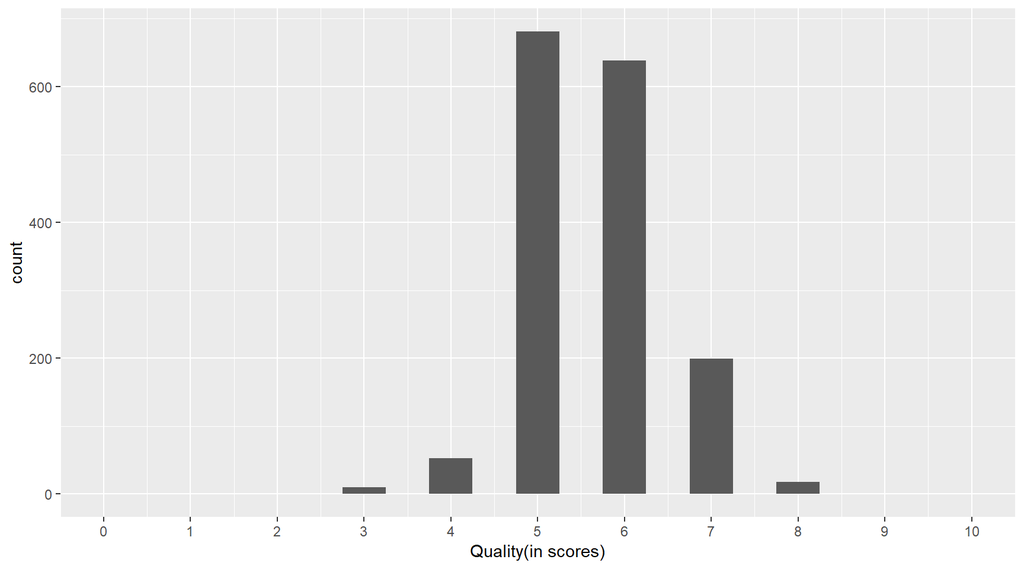

```
##    Min. 1st Qu.  Median    Mean 3rd Qu.    Max.
##   3.000   5.000   6.000   5.636   6.000   8.000
```

```
##
##   3   4   5   6   7   8
##  10  53 681 638 199  18
```

> It seems like the majority of the red wines’ quality is 5 and 6. I am also interested in exploring other chemical properties of red wines such as alcohol, pH, chlorides, ect.

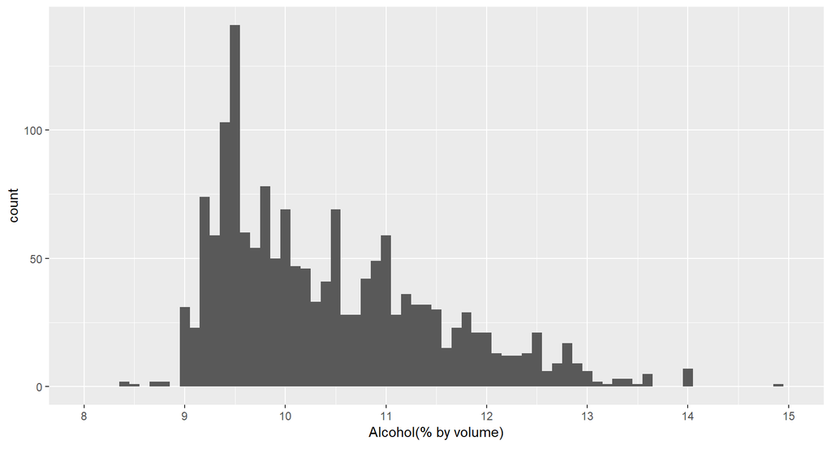

> This plot is skewed to right and the peak of percent of acohol in red wine is mostly around 9.5.

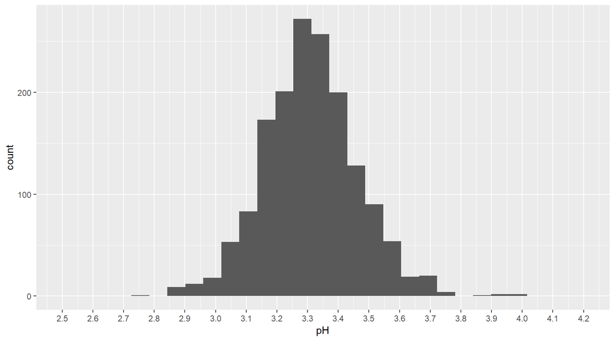

```
##    Min. 1st Qu.  Median    Mean 3rd Qu.    Max.
##   2.740   3.210   3.310   3.311   3.400   4.010
```

```
##
## 2.74 2.86 2.87 2.88 2.89  2.9 2.92 2.93 2.94 2.95 2.98 2.99    3 3.01 3.02
##    1    1    1    2    4    1    4    3    4    1    5    2    6    5    8
## 3.03 3.04 3.05 3.06 3.07 3.08 3.09  3.1 3.11 3.12 3.13 3.14 3.15 3.16 3.17
##    6   10    8   10   11   11   11   19    9   20   13   21   34   36   27
## 3.18 3.19  3.2 3.21 3.22 3.23 3.24 3.25 3.26 3.27 3.28 3.29  3.3 3.31 3.32
##   30   25   39   36   39   32   29   26   53   35   42   46   57   39   45
## 3.33 3.34 3.35 3.36 3.37 3.38 3.39  3.4 3.41 3.42 3.43 3.44 3.45 3.46 3.47
##   37   43   39   56   37   48   48   37   34   33   17   29   20   22   21
## 3.48 3.49  3.5 3.51 3.52 3.53 3.54 3.55 3.56 3.57 3.58 3.59  3.6 3.61 3.62
##   19   10   14   15   18   17   16    8   11   10   10    8    7    8    4
## 3.63 3.66 3.67 3.68 3.69  3.7 3.71 3.72 3.74 3.75 3.78 3.85  3.9 4.01
##    3    4    3    5    4    1    4    3    1    1    2    1    2    2
```

> The shape of pH values is normally distributed. The range of pH is between 2.74 and 4.01. Majority red wine has pH around 3.3.

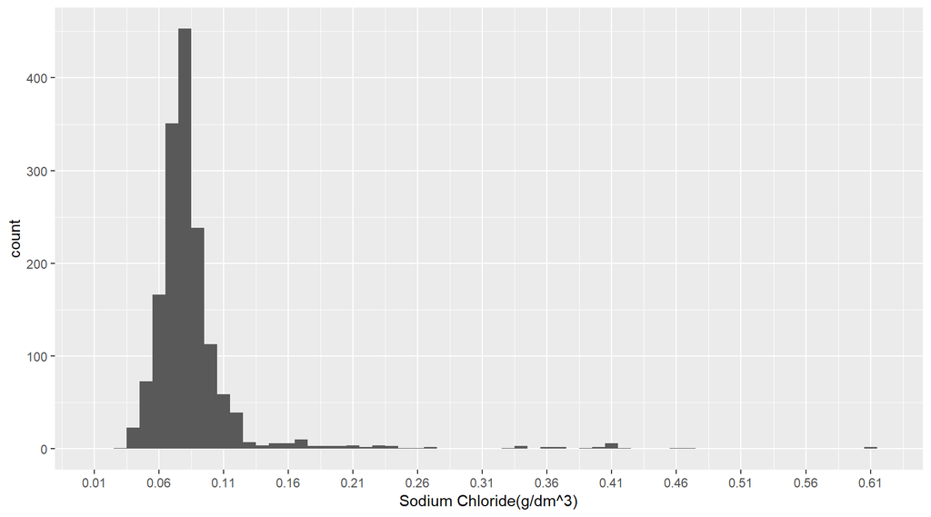

> There are outliers in red wine chlorides values. The amount of salt in red wine has a peak around 0.08.

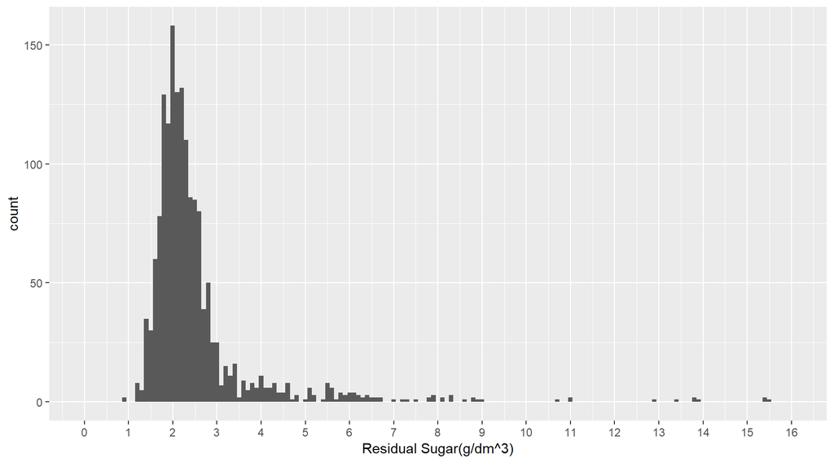

> The amount of sugar remaining peaks around 2. Most of the red wine residual sugar is less than 3.

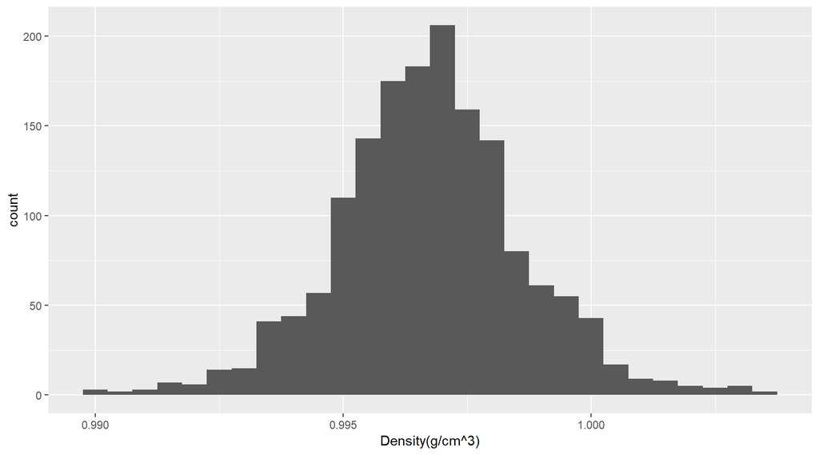

> The density reaches peak around 0.997. The shape of this plot is normally distributed.

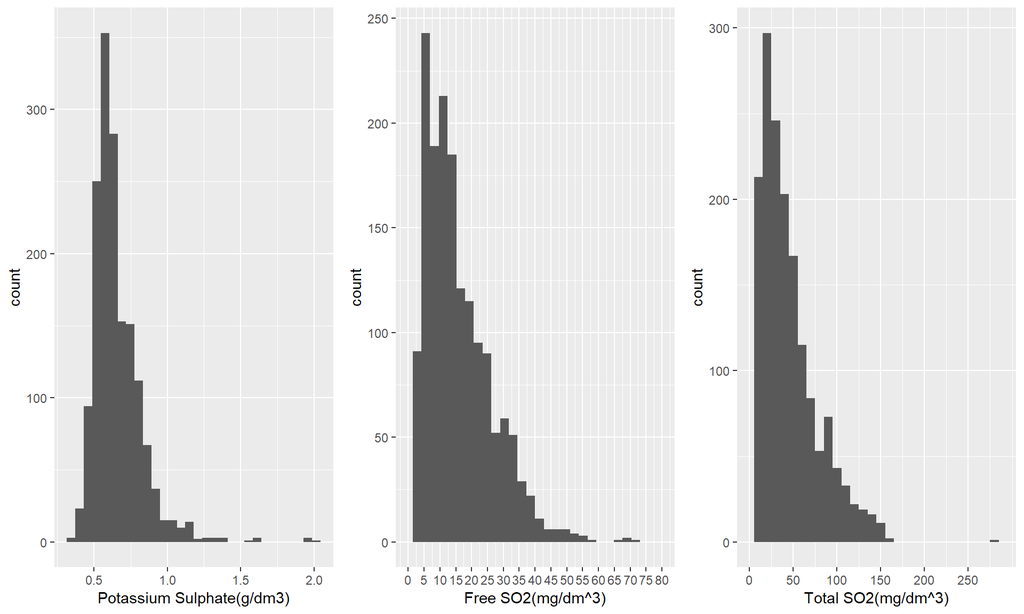

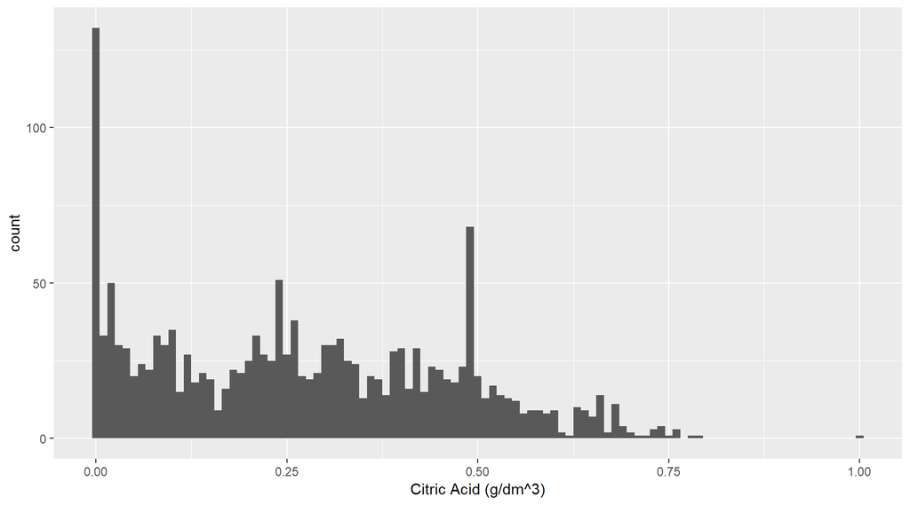

> The citric acid levels vary a lot among the red wines. A lot of red wines do not have added citric acid. There are also other two peaks aroun 0.25 and 0.5.

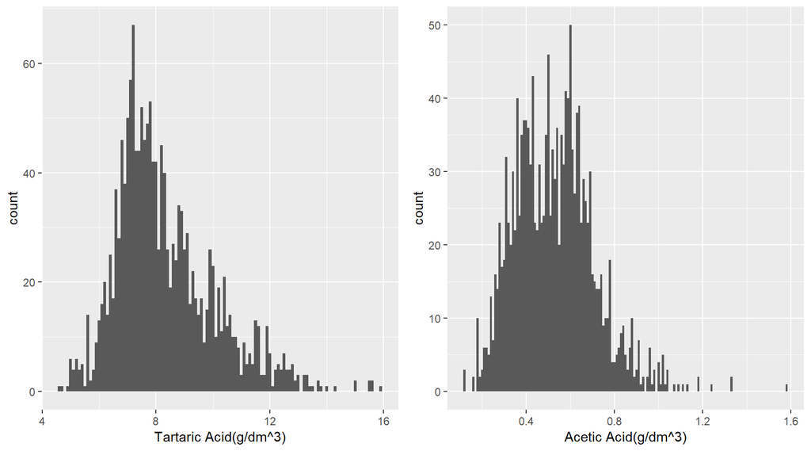

> There is no categorical variable in this dataset, so I can not do any boxplot. In order to explore further in the following analysis, a categorical variable called quality.level is created by dividing quality into three levels.

# Univariate Analysis

### What is the structure of your dataset?

> There are 1599 red wine samples in the dataset with 11 chemical properties(alcohol, pH, density, chlorides, residual sugar, sulphates, free sulfur dioxide, total sulfur dioxide, citric acid, fixed acidity, volatile acidity). The median quality of the red wines is 6. The max quality is 8 and min quality is 3.

### What is/are the main feature(s) of interest in your dataset?

> Alcohol and quality are the main features of this data that I am interested in. I want to know how alcohol content affects the red wine quality. However, other chemical properties such as pH, residual sugar, acidity, sulfur, chlorides may also contribute to the red wine quality.

### What other features in the dataset do you think will help support your investigation into your feature(s) of interest?

> Residual sugar, acid, sulfur, chloride affect red wine quality together with alcohol percentage.

### Did you create any new variables from existing variables in the dataset?

> Yes, I created a new categorical variable called quality.level by cutting variable quality into 3 levels (3,5], (5, 6] and (6, 8].

### Of the features you investigated, were there any unusual distributions? Did you perform any operations on the data to tidy, adjust, or change the form of the data? If so, why did you do this?

> No.

# Bivariate Plots Section

[figure not shown]

> None of a single chemical properties has a strong correlation with red wine quality, including alcohol which has the highest correlation coefficient(0.455) among all. Some of the chemical properties have a moderate correaltion with each other, such as pH and fixed acidity, density and fixed acidity, free sulfur dioxide and total sulfur dioxide. It is interesting to look closer at scatter plots involving quality and those chemical properties. It is also necessary to explore some relationships between two chemical properties.

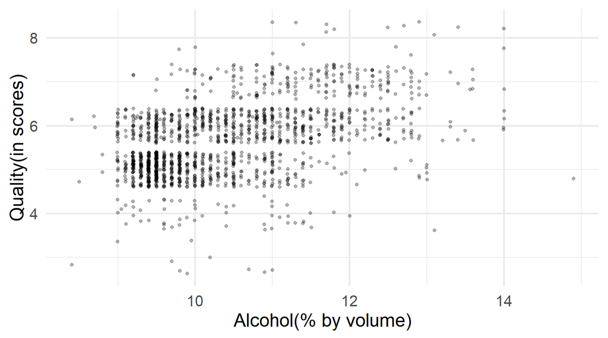

> Alcohol does not affect red wine quality in a linear trend.

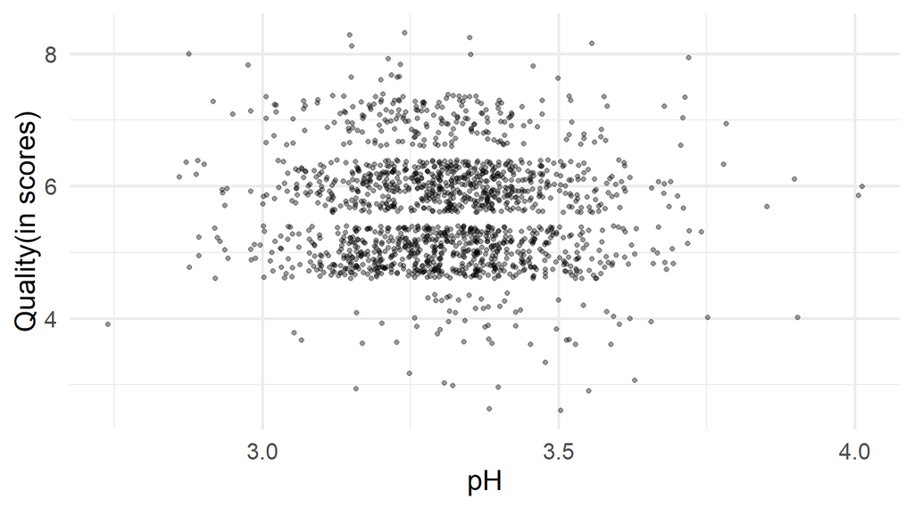

> pH level and red wine quality are not correlated.

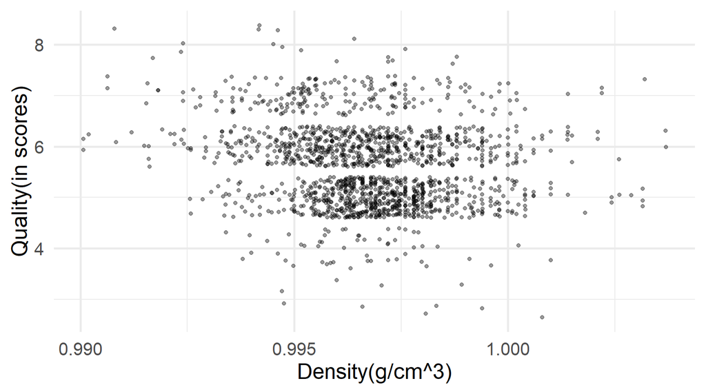

> Density does not affect red wine quality alone.

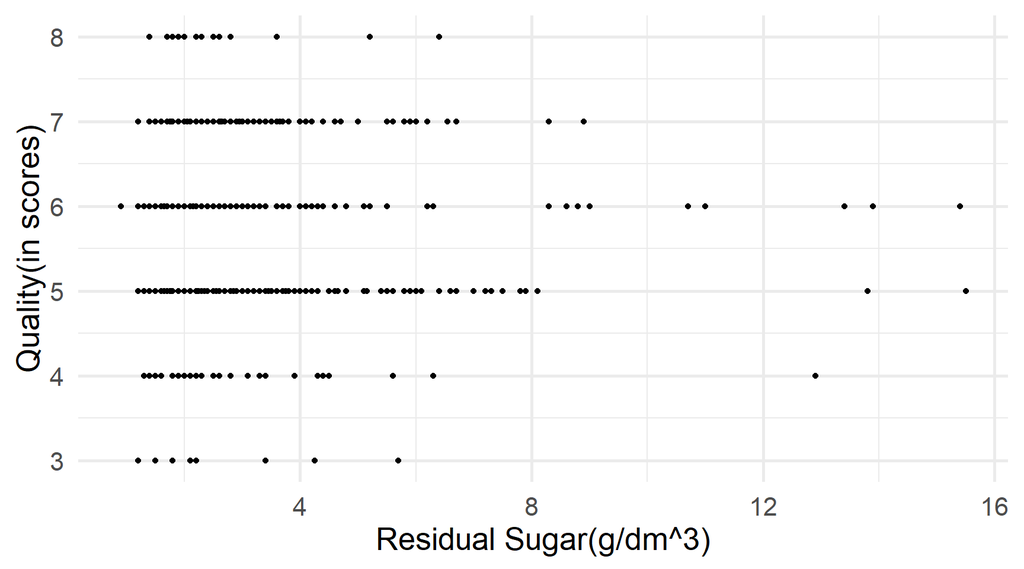

> Residual sugar alone does not affect red wine quality in a positive or negative trend.

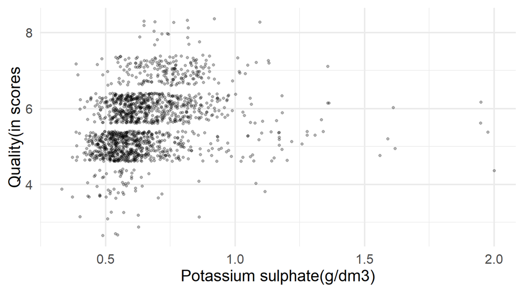

> Sulphates(Potassium sulphate) level does not seem to correlate with red wine quality.

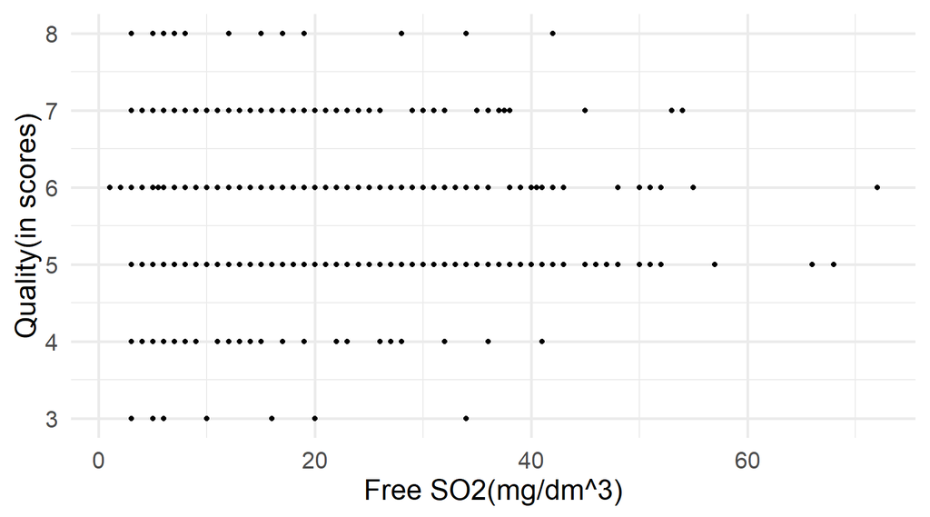

> Free sulfur dioxide level does not have a strong correlation with red wine quality.

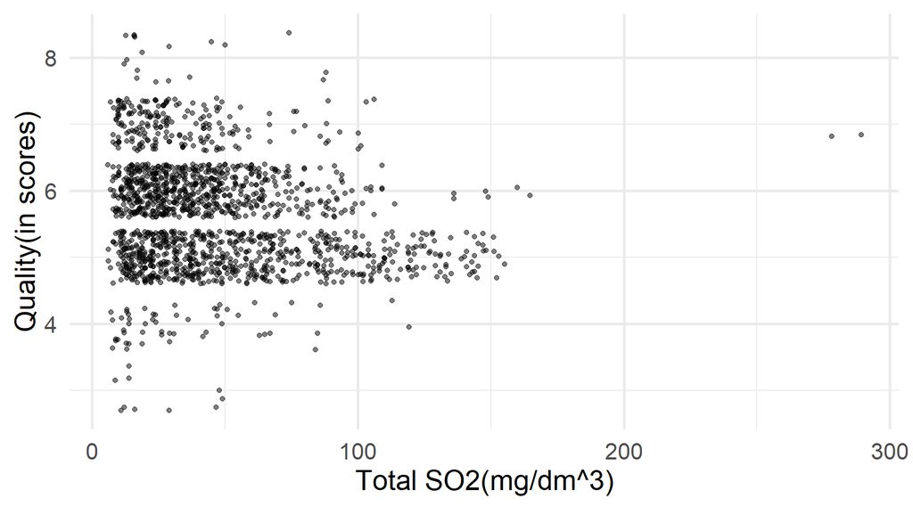

> Total sulfur dioxide(SO2) level alone does not affect red wine overal quality.

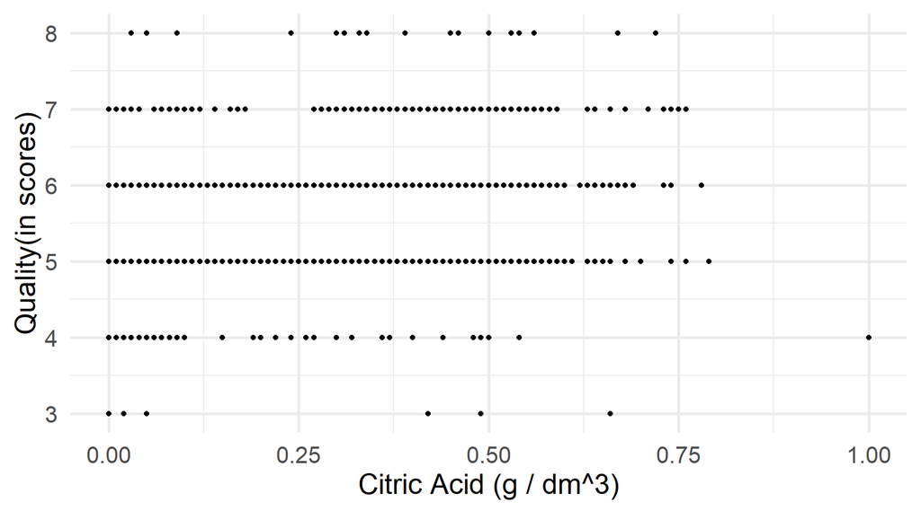

> Citric acid and red wine quality are not correlated.

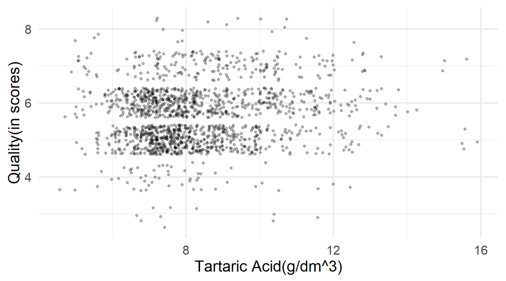

> Fixed acidity(Tartaric Acid) does not affect the red wine quality in a positive or negative way.

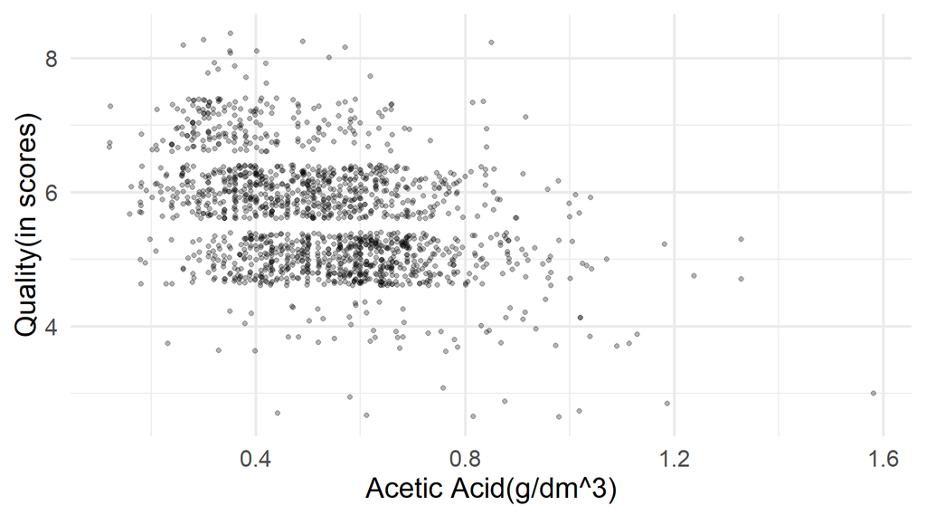

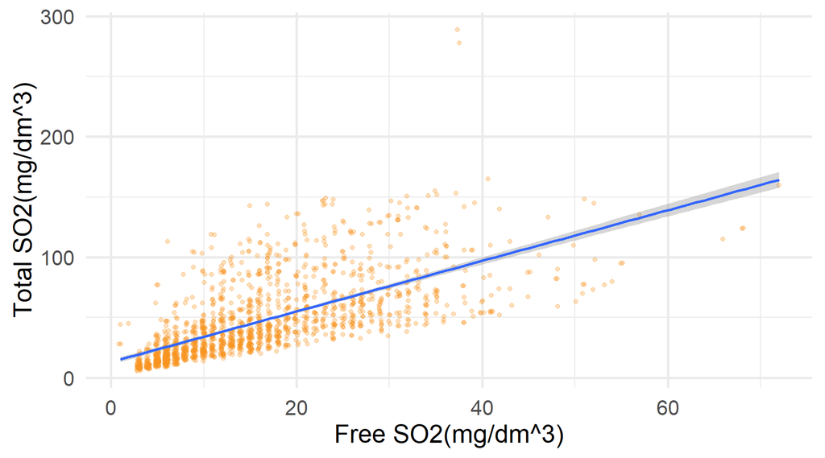

> Free sulfur dioxide(SO2) and total sulfur dioxide(SO2) levels are in a strong positive relationship.

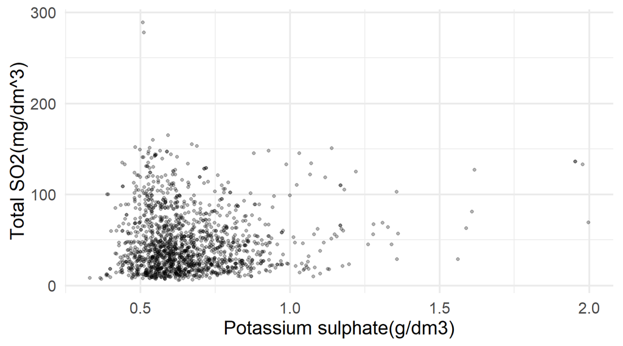

> Sulphates(Potassium sulphate) and total sulfur dioxide levals are not in a positive relationship.

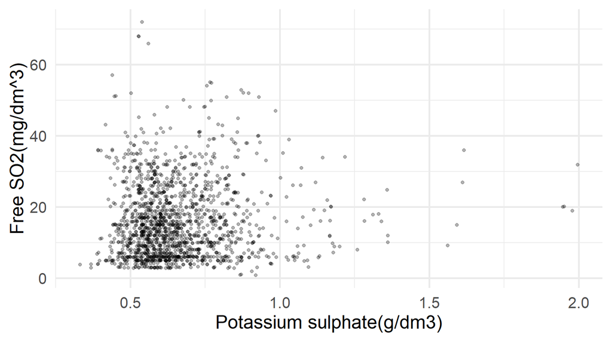

> Sulphates level does not have a strong relationship with free sulfur dioxide level.

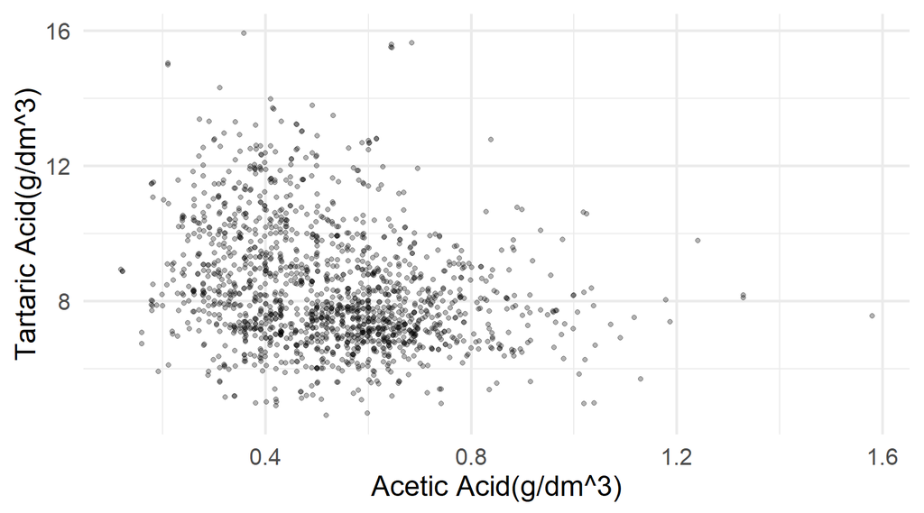

> Fixed acidity and volatile acidity does not show a relationship.

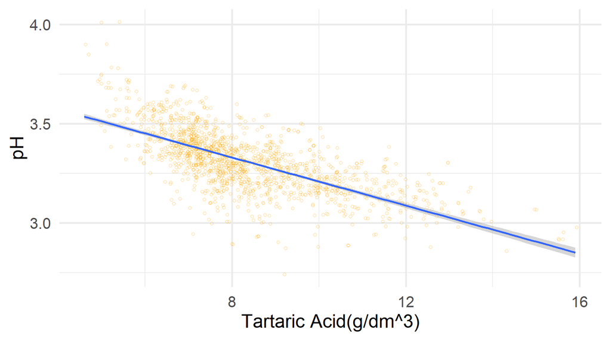

> The pH level and fixed acidity(tartaric acid) are strongly related.

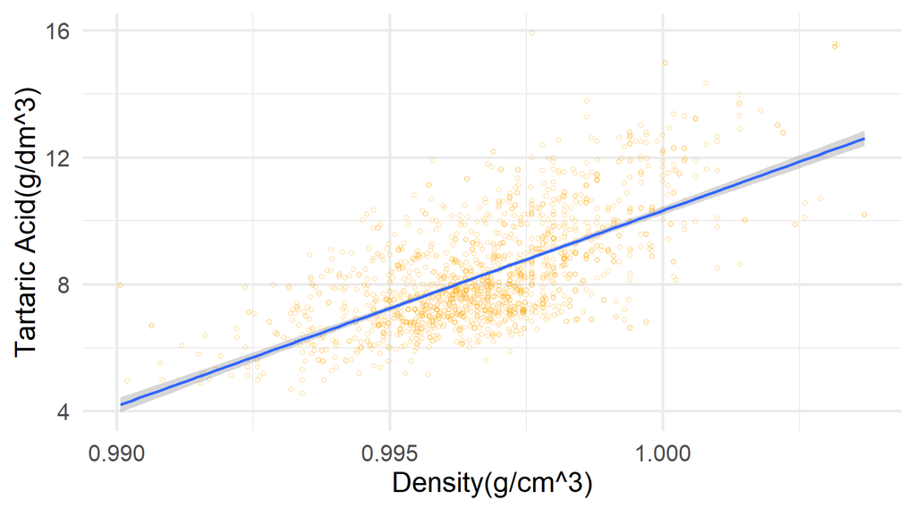

> The fixed acidity increased with the increase of density. It has a positive relationship.

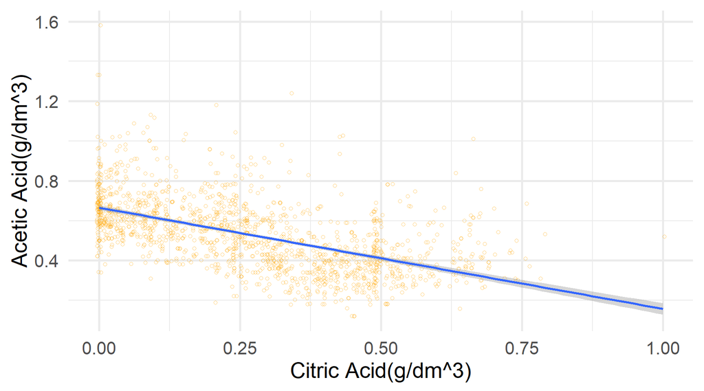

> With the increase of citric acid, the volatile acidity(acetic acid) decreased. A line was drawn to see the trend.

# Bivariate Analysis

### Talk about some of the relationships you observed in this part of the investigation. How did the feature(s) of interest vary with other features in the dataset?

> Alcohol percentage does not seem to have a strong correlation with red wine quality. None of the chemical properties alone has a a strong correlation with red wine quality.

### Did you observe any interesting relationships between the other features (not the main feature(s) of interest)?

> Yes, the correlation coefficient between free sulfur dioxide and total sulfur dioxide is 0.68. The correlation coefficient between fixed acidity and pH is -0.682. It is easy to understand that with the increase of fixed acidity, the pH is decreased. The correlation coefficient between density and fixed acidity is 0.666. The correlation coefficient between citric acid and fixed acidity is 0.661. The correlation coefficient between citric acid and volatile acidity is -0.546.

### What was the strongest relationship you found?

> Fixed acidity and pH have the strongest relationship among all.

# Multivariate Plots Section

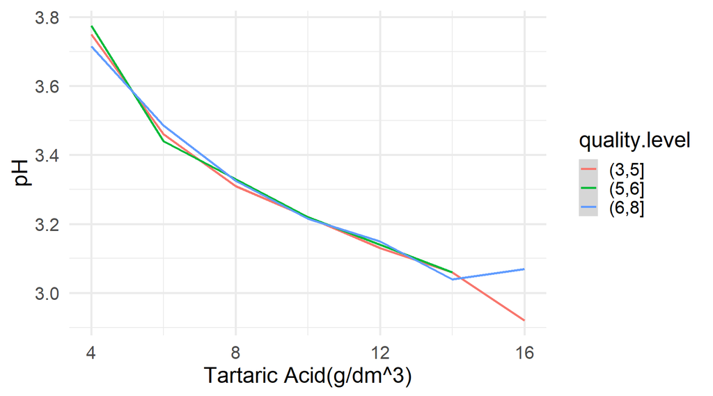

> Smooth lines were made to show the relationship between pH and fixed acidity(tartaric acid). The increased fixed acidity results in decreased pH median levels. But this change does not seem to have an impact on overal red wine quality.

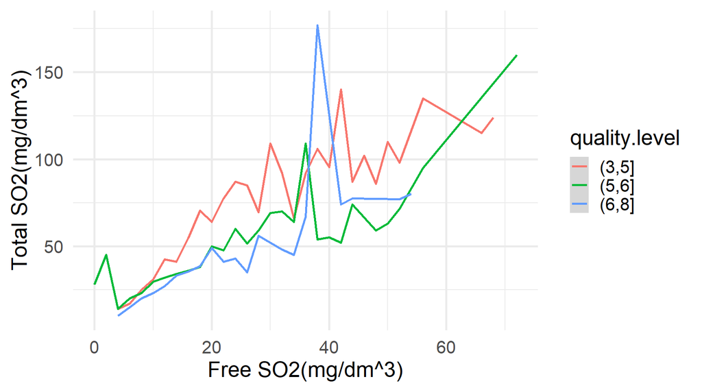

> The line plot shows that lower quality redwine usually has a higher total sulfur dioxide. Since free sulfur dioxide has a strong positive correlation with total sulfur dioxide, I am interested in knowing if the ratio of free sulfur dioxide in total sulfur dioxide has an impact on red wine quality.

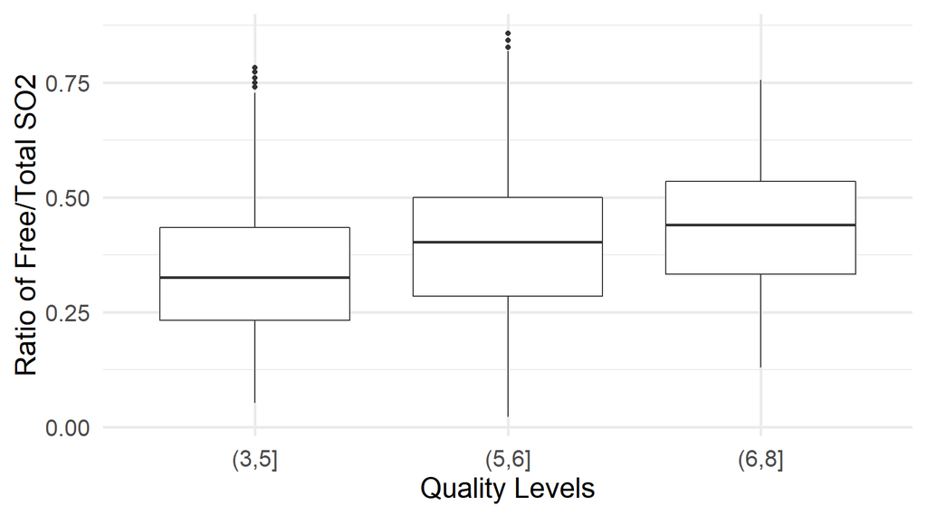

> I made a boxplot to show the trend. The boxplot shows that the higher quality wine has a higher median ratio of free sulfur dioxide.

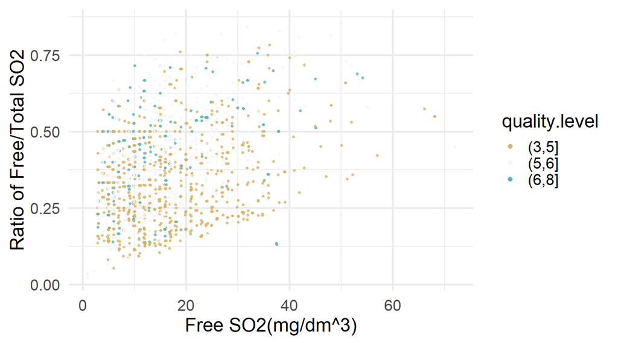

> The scatter plot also shows that the red wine with higher quality usually has higher free sulfur dioxide ratio.

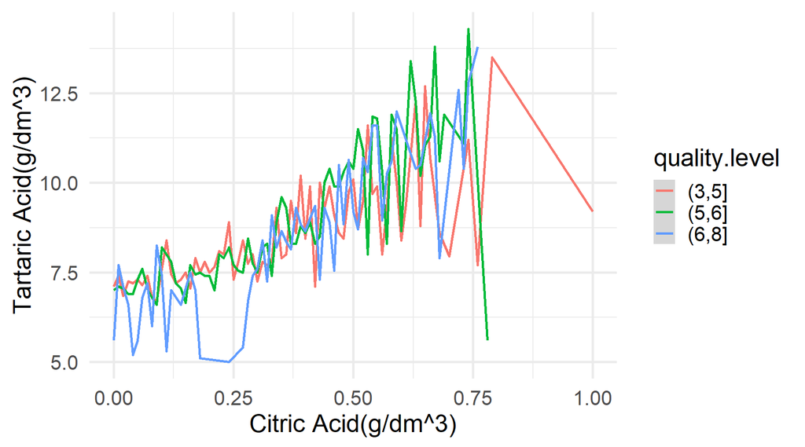

> The citric acid and fixed acidity(tartaric acid) has a positive correlation. It does not seem there is any overal impact on red wine quality with the changes.